# Churn_Project

### Project Title - Customer Churn Prediction

### Import Libraries

```python
import pandas as pd
import matplotlib.pyplot as plt
import seaborn as sns
import mysql.connector

from sqlalchemy import create_engine
from sklearn.model_selection import train_test_split
from sklearn.preprocessing import LabelEncoder
from sklearn.ensemble import RandomForestClassifier
from sklearn.metrics import accuracy_score, classification_report, confusion_matrix
from sklearn.metrics import ConfusionMatrixDisplay
```

### Load Dataset

```python
import pandas as pd
df = pd.read_csv("Churn_Modelling_file.csv")
print(df.head())
print(df.info())
```

```
   RowNumber  CustomerId   Surname  CreditScore Geography  Gender   Age  \
0          1    15634602  Hargrave          619    France  Female  42.0
1          2    15647311      Hill          608     Spain  Female  41.0
2          3    15619304      Onio          502    France  Female  42.0
3          4    15701354      Boni          699    France  Female  39.0
4          5    15737888  Mitchell          850     Spain  Female  43.0

   Tenure    Balance  NumOfProducts  HasCrCard  IsActiveMember  \
0       2       0.00              1        1.0             1.0
1       1   83807.86              1        0.0             1.0
2       8  159660.80              3        1.0             0.0
3       1       0.00              2        0.0             0.0
4       2  125510.82              1        1.0             1.0

   EstimatedSalary  Exited
0        101348.88       1
1        112542.58       0
2        113931.57       1
3         93826.63       0
4         79084.10       0
<class 'pandas.core.frame.DataFrame'>
RangeIndex: 10000 entries, 0 to 9999
Data columns (total 14 columns):
 #   Column           Non-Null Count  Dtype
---  ------           --------------  -----
 0   RowNumber        10000 non-null  int64
 1   CustomerId       10000 non-null  int64
 2   Surname          10000 non-null  object
 3   CreditScore      10000 non-null  int64
 4   Geography        10000 non-null  object
 5   Gender           10000 non-null  object
 6   Age              10000 non-null  float64
 7   Tenure           10000 non-null  int64
 8   Balance          10000 non-null  float64
 9   NumOfProducts    10000 non-null  int64
 10  HasCrCard        10000 non-null  float64
 11  IsActiveMember   10000 non-null  float64
 12  EstimatedSalary  10000 non-null  float64
 13  Exited           10000 non-null  int64
dtypes: float64(5), int64(6), object(3)
memory usage: 1.1+ MB
None
```

```python
print(df.isnull().sum())
```

```
RowNumber          0
CustomerId         0
Surname            0
CreditScore        0
Geography          0
Gender             0
Age                0
Tenure             0
Balance            0
NumOfProducts      0
HasCrCard          0
IsActiveMember     0
EstimatedSalary    0
Exited             0
dtype: int64
```

```python
print(df.shape)
```

[output not shown]

### Removing Duplicate Customer Records

```python
df = df.drop_duplicates(subset='CustomerId')
print("Rows after dropping duplicates:", df.shape[0])
```

```
Rows after dropping duplicates: 10000
```

### Creating SQLAlchemy Engine for MySQL

```python
from sqlalchemy import create_engine
import pandas as pd

# Replace these with your actual values
username = 'root'
password = 'EMPP@123swe08'
host = 'localhost'         # or 127.0.0.1
database ='churn_db'  # the name of your MySQL DB

# Create SQLAlchemy enginefrom sqlalchemy import crate_engine
engine = create_engine("mysql+mysqlconnector://root:EMPP%40123swe08@localhost/churn_db")
```

### Deleting Existing Records from MySQL Table

```python
from sqlalchemy import create_engine, text

engine = create_engine('mysql+mysqlconnector://root:EMPP%40123swe08@localhost/churn_db')

with engine.begin() as connection:
     connection.execute(text("DELETE FROM customers"))
```

```python
df.to_sql(name='customers', con=engine, if_exists='append', index=False)
```

```
10000
```

### Inserting Pandas DATAFRAME into MySQL Table

```python
import mysql.connector

conn = mysql.connector.connect(
    host='localhost',
    user='root',
    password='EMPP@123swe08',
    database='churn_db',
)
cursor = conn.cursor()

query = """
INSERT INTO customers (
    CustomerID, Surname, CreditScore, Geography, Gender,
    Age, Tenure, Balance, NumOfProducts,
    HasCrCard, IsActiveMember, EstimatedSalary, Exited
) VALUES (%s, %s, %s, %s, %s, %s, %s, %s, %s, %s, %s, %s, %s)
"""

values = (
    15692345, 'Smith', 600, 'Germany', 'Male',
    45, 5, 150000.0, 2, 1, 1, 100000.0, 0
)

cursor.execute(query, values)
conn.commit()

print("Row inserted successfully.")

cursor.close()
conn.close()
```

```
Row inserted successfully.
```

### EDA - Expolatory Data Analaysis

```python
from sqlalchemy import create_engine
import pandas as pd

engine = create_engine("mysql+mysqlconnector://root:EMPP%40123swe08@localhost/churn_db")

query = "SELECT COUNT(*) AS total_customers, SUM(Exited) AS total_churned FROM customers"
df = pd.read_sql(query, engine)
print(df)
```

```
   total_customers  total_churned
0            10001         2037.0
```

```python
import pandas as pd
import mysql.connector

df = pd.read_csv("churn_modelling_file.csv")

conn = mysql.connector.connect(
    host='localhost',
    user='root',
    password='EMPP@123swe08',
    database='churn_db'
)
```

[figure not shown]

```python
from sqlalchemy import create_engine
import pandas as pd
import seaborn as sns
import matplotlib.pyplot as plt

engine = create_engine("mysql+mysqlconnector://root:EMPP%40123swe08@localhost/churn_db")

queryy = """SELECT Geography, COUNT(*) AS total, SUM(Exited) AS churned,
            ROUND(SUM(Exited)/COUNT(*)*100, 2) AS churn_rate
            FROM customers GROUP BY Geography"""
df = pd.read_sql(query, engine)

sns.barplot(data=df, x='Geography', y='Exited')
plt.title("Churn Rate by Geography")
plt.show()
```

```python
print(df.columns)
print(df.head())
```

```
Index(['total_customers', 'total_churned'], dtype='object')
   total_customers  total_churned
0            10001         2037.0
```

```python
query = "SELECT * FROM customers"
df = pd.read_sql(query, engine)

print(df.columns)
print(df.head())
```

```
Index(['RowNumber', 'CustomerId', 'Surname', 'CreditScore', 'Geography',
       'Gender', 'Age', 'Tenure', 'Balance', 'NumOfProducts', 'HasCrCard',
       'IsActiveMember', 'EstimatedSalary', 'Exited'],
      dtype='object')
   RowNumber  CustomerId   Surname  CreditScore Geography  Gender   Age  \
0     1288.0    15565701     Ferri          698     Spain  Female  39.0
1     4199.0    15565706  Akobundu          612     Spain    Male  35.0
2     7091.0    15565714  Cattaneo          601    France    Male  47.0
3     2021.0    15565779      Kent          627   Germany  Female  30.0
4     3698.0    15565796  Docherty          745   Germany    Male  48.0

   Tenure   Balance  NumOfProducts  HasCrCard  IsActiveMember  \
0       9  161994.0              1        0.0             0.0
1       1       0.0              1        1.0             1.0
2       1   64430.1              2        0.0             1.0
3       6   57809.3              1        1.0             0.0
4      10   96048.5              1        1.0             0.0

   EstimatedSalary  Exited
0          90212.4       0
1          83256.3       1
2          96518.0       0
3         188258.0       0
4          74510.6       0
```

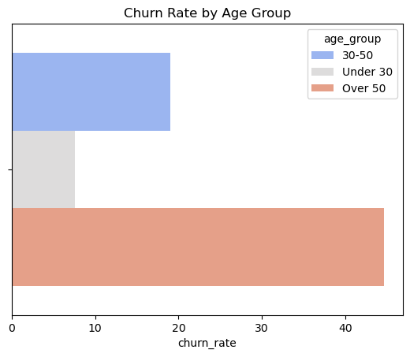

```python
from sqlalchemy import create_engine
import pandas as pd
import seaborn as sns
import matplotlib.pyplot as plt

engine = create_engine("mysql+mysqlconnector://root:EMPP%40123swe08@localhost/churn_db")

query = """SELECT
  CASE
     WHEN Age < 30 THEN 'Under 30'
     WHEN Age BETWEEN 30 AND 50 THEN '30-50'
     ELSE 'Over 50'
  END AS age_group,
  COUNT(*) AS total,
  SUM(Exited) AS churned,
  ROUND(SUM(Exited)/COUNT(*)*100, 2) AS churn_rate
FROM customers GROUP BY age_group"""

df = pd.read_sql(query, engine)

sns.barplot(data=df, hue='age_group', x='churn_rate', palette='coolwarm', legend=True)
plt.title('Churn Rate by Age Group')
plt.show()
```

**Interpretation** - Customers over 50 show the highest churn rate, followed by those in the 30-50 range. Younger customers under 30 churn the least. Age is clearly a strong factor in customer retention.

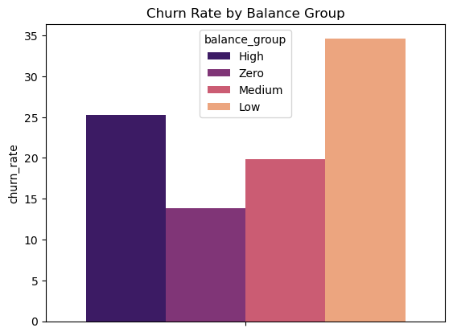

```python
from sqlalchemy import create_engine
import pandas as pd
import seaborn as sns
import matplotlib.pyplot as plt

engine = create_engine("mysql+mysqlconnector://root:EMPP%40123swe08@localhost/churn_db")

query = """SELECT
  CASE
    WHEN Balance = 0 THEN 'Zero'
    WHEN Balance BETWEEN 1 AND 50000 THEN 'Low'
    WHEN Balance BETWEEN 50001 AND 100000 THEN 'Medium'
     ELSE 'High'
  END AS balance_group,
  COUNT(*) AS total,
  SUM(Exited) AS churned,
  ROUND(SUM(Exited)/COUNT(*)*100, 2) AS churn_rate
FROM customers GROUP BY balance_group"""

df = pd.read_sql(query, engine)

sns.barplot(data=df, hue='balance_group', y='churn_rate', palette='magma',)
plt.title('Churn Rate by Balance Group')
plt.show()
```

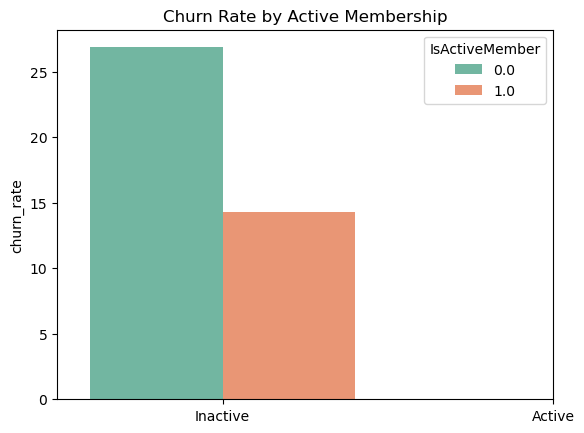

```python
from sqlalchemy import create_engine
import pandas as pd
import seaborn as sns
import matplotlib.pyplot as plt

engine = create_engine("mysql+mysqlconnector://root:EMPP%40123swe08@localhost/churn_db")

query = """SELECT IsActiveMember,
       COUNT(*) AS churned,
       SUM(Exited) AS churned,
       ROUND(SUM(Exited)/COUNT(*)*100, 2) as churn_rate
FROM customers GROUP BY IsActiveMember"""

df = pd.read_sql(query, engine)

sns.barplot(data=df, hue='IsActiveMember', y='churn_rate', palette='Set2', legend=True)
plt.title('Churn Rate by Active Membership')
plt.xticks([0, 1], ['Inactive', 'Active'])
plt.show()
```

**Interpretation** - Inactive customers have a much higher churn rate than active ones. This strongly suggests that active engagement is critical to reducing churn.

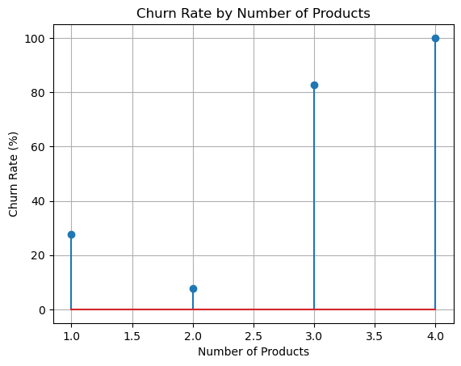

```python
from sqlalchemy import create_engine
import pandas as pd
import seaborn as sns
import matplotlib.pyplot as plt

engine = create_engine("mysql+mysqlconnector://root:EMPP%40123swe08@localhost/churn_db")

query = """SELECT NumOfProducts,
       COUNT(*) AS total,
       SUM(Exited) AS churned,
       ROUND(SUM(Exited)/COUNT(*)*100, 2) AS churn_rate
FROM customers GROUP BY NumOfProducts"""

df = pd.read_sql(query, engine)

plt.stem(df['NumOfProducts'], df['churn_rate'])
plt.xlabel('Number of Products')
plt.ylabel('Churn Rate (%)')
plt.title('Churn Rate by Number of Products')
plt.grid(True)
plt.show()
```

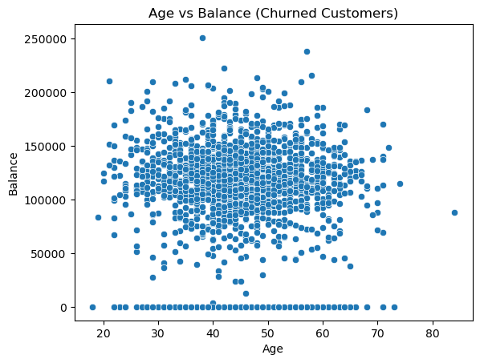

```python
from sqlalchemy import create_engine
import pandas as pd
import seaborn as sns
import matplotlib.pyplot as plt

engine = create_engine("mysql+mysqlconnector://root:EMPP%40123swe08@localhost/churn_db")

query ="""SELECT Age, Balance
FROM customers WHERE Exited = 1"""

df = pd.read_sql(query, engine)

sns.scatterplot(data=df, x='Age', y='Balance')
plt.title('Age vs Balance (Churned Customers)')
plt.show()
```

**Interpretation** - Among churned customers, those aged 40-60 with high balances are more common. There is no clear linear relationship, but some middle-aged high-balance customers are at higher churn risk.

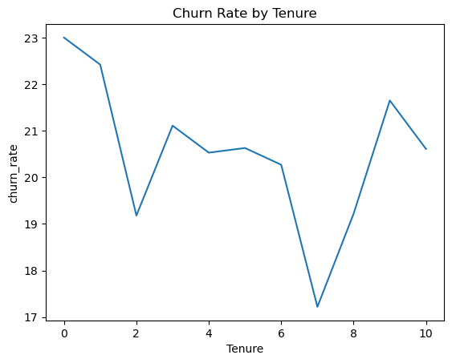

```python
from sqlalchemy import create_engine
import pandas as pd
import seaborn as sns
import matplotlib.pyplot as plt

engine = create_engine("mysql+mysqlconnector://root:EMPP%40123swe08@localhost/churn_db")

query ="""SELECT Tenure, ROUND(SUM(Exited)/COUNT(*)*100, 2) AS churn_rate
FROM customers GROUP BY Tenure ORDER BY Tenure"""

df = pd.read_sql(query, engine)

sns.lineplot(data=df, x='Tenure', y='churn_rate')
plt.title('Churn Rate by Tenure')
plt.show()
```

**Interpretation** - Churn appears to fluctuate across tenure levels, with no strong trend. However, some mid-tenure customers show lower churn, suggesting tenure alone doesn't drive churn - but may combine with other factors.

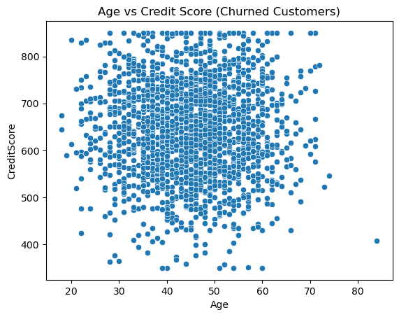

```python
from sqlalchemy import create_engine
import pandas as pd
import seaborn as sns
import matplotlib.pyplot as plt

engine = create_engine("mysql+mysqlconnector://root:EMPP%40123swe08@localhost/churn_db")

query = """SELECT Age, CreditScore
FROM customers WHERE Exited = 1"""

df = pd.read_sql(query, engine)

sns.scatterplot(data=df, x='Age', y='CreditScore')
plt.title('Age vs Credit Score (Churned Customers)')
plt.show()
```

**Interpretation** - There is no strong pattern between age and credit score among churned customers. The data is widely spread, indicating churn occurs all ages and score ranges - credit score alone doesn't explain churn.

### Split Data and Feature Encoding

```python
from sqlalchemy import create_engine
import pandas as pd
import seaborn as sns
import matplotlib.pyplot as plt

engine = create_engine("mysql+mysqlconnector://root:EMPP%40123swe08@localhost/churn_db")

from sklearn.model_selection import train_test_split
from sklearn.preprocessing import LabelEncoder

#drop ID-related or text columns
x = df.drop(['RowNumber', 'CustomerId', 'Surname', 'Exited'], axis=1)
y = df['Exited']

#Encode Gender and Geography
x['Gender'] = LabelEncoder().fit_transform(x['Gender'])
x['Geography'] = LabelEncoder().fit_transform(x['Geography'])

#Train-test split
x_train, x_test, y_train, y_test = train_test_split(x, y, test_size=0.2, random_state=42)
```

### Model Training and Evaluation

```python
#train basic ML model

from sklearn.ensemble import RandomForestClassifier
from sklearn.metrics import accuracy_score, classification_report, confusion_matrix

model = RandomForestClassifier(random_state=42, class_weight='balanced')
model.fit(x_train, y_train)

#predict
y_pred = model.predict(x_test)

#evaluate
print("Accuracy:", accuracy_score(y_test, y_pred))
print("Classification Report:\n", classification_report(y_test, y_pred))
```

```
Accuracy: 0.8660669665167416
Classification Report:
               precision    recall  f1-score   support

           0       0.88      0.97      0.92      1607
           1       0.78      0.45      0.57       394

    accuracy                           0.87      2001
   macro avg       0.83      0.71      0.74      2001
weighted avg       0.86      0.87      0.85      2001
```

### Model Evaluation - Random Forest Classifier (with class_weight='balance')

The model was trained using a Random Forest Classifier with 'class_weight='balanced' to handle class imbalance.

### Key Metrics:

**Accuracy : 87%** Precision (churn = 1) : 0.78 **Recall (churn = 1) : 0.45** F1-Score (churn = 1) : 0.57

### Interpretation:

--The model performs very well on non-churned customers (class 0) with a high recall of 97% and F1-Score of 0.92. --For churned customers (class 1), the recall is low (45%), meaning the model is still missing many actual churn cases. --Precision for class 1 is decent (0.78), indicating that when the model predicts churn, it's often correct.

### Model Evaluation - Accuracy and Classification Report

```python
from sklearn.metrics import accuracy_score, classification_report, confusion_matrix

y_pred = model.predict(x_test)

print("Accuracy:", accuracy_score(y_test, y_pred))
print("Classification Report:\n", classification_report(y_test, y_pred))
```

```
Accuracy: 0.8660669665167416
Classification Report:
               precision    recall  f1-score   support

           0       0.88      0.97      0.92      1607
           1       0.78      0.45      0.57       394

    accuracy                           0.87      2001
   macro avg       0.83      0.71      0.74      2001
weighted avg       0.86      0.87      0.85      2001
```

### Visualizing the Confusion Matrix

```
<sklearn.metrics._plot.confusion_matrix.ConfusionMatrixDisplay at 0x2361b642960>
```

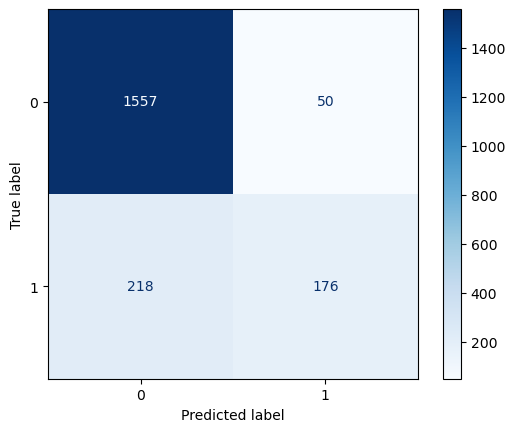

```python
from sklearn.metrics import ConfusionMatrixDisplay

ConfusionMatrixDisplay.from_estimator(model, x_test, y_test, cmap="Blues")
```

### Feature Importance Visualization

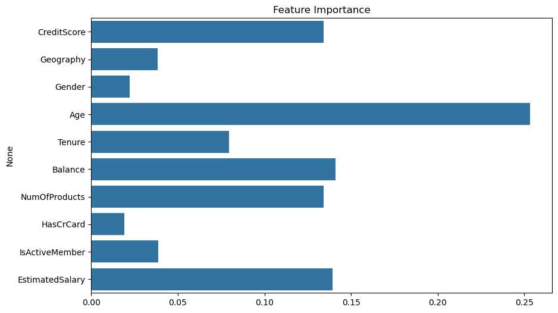

```python
import matplotlib.pyplot as plt
import seaborn as sns

importance = model.feature_importances_
features = x.columns

plt.figure(figsize=(10,6))
sns.barplot(x=importance, y=features)
plt.title("Feature Importance")
plt.show()
```

### Interpretation of Results

*It predicts Customer Churn (Exited = 1) based on features like credit score, age, balance, number of products, etc.

*I evaluated the model using a confusion matrix and a classification report, which show:

--Reasonable accuracy

### Final Conclusion:

All necessary steps like data cleaning, EDA, feature preparation, model training, and evaluation were followed.

This project shows ability to handle a complete ML pipeline, making it a strong addition to your resume.

For future improvement, consider:

Handling class imbalance more deeply (e.g., SMOTE)

Hyperparameter tuning for better performance

### Save Model

```python
import joblib
joblib.dump(model, 'churn_model.cm')
```

```
['churn_model.cm']
```

```python
import joblib

model = joblib.load('churn_model.cm')

predictions = model.predict(x_test)
print(predictions)
```

```
[0 0 0 ... 0 1 0]
```